# Practice HW 3

Now let’s create a boxplot to see the data distrbution by gorups

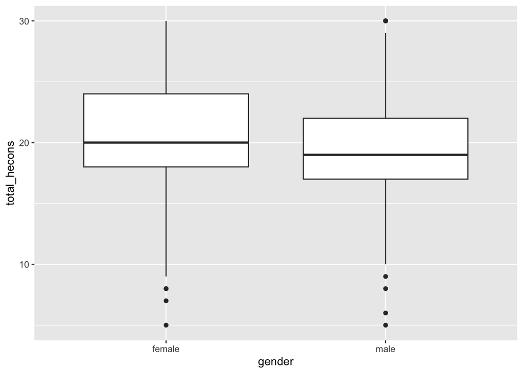

```r
ggplot(hecons_gender_subset, aes(x=gender, y=total_hecons))+
  geom_boxplot()
```

It seems that male respondents tend to have fewer health concern indices.

Now let’s get back to the test

RQ, H0 and H1:

Let’s state the research question, null hypothesis and alternative hypothesis for the following analysis to be carried out.

RQ: Is there any statistically significant mean difference in health concerns between the male and female respondents?

H0: There is no statistically significant mean difference in health concerns between the male and female respondents. H1: There is a statistically significant mean difference in health concerns between the male and female respondents.

Before we carry out the T-test, we need to see if the assumptions for the test are met. If not, we will make corrections into the test and will opt for the non-parametric test.

Assumption 1. The observations should be independent. It is met as all observations represent different people.

Assumption 2. The normality of the data.

We have checked before the descriptive statistics and it seemed from the histogram that the data is normal.

Histogram:

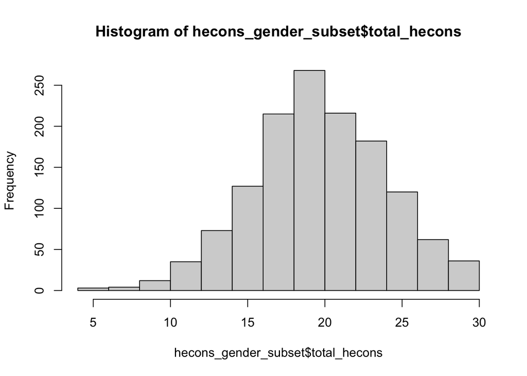

```r
hist(hecons_gender_subset$total_hecons)
```

```r
describe(hecons_gender_subset$total_hecons)
```

```
##    vars    n  mean   sd median trimmed  mad min max range skew kurtosis   se
## X1    1 1353 20.14 4.32     20   20.17 4.45   5  30    25 -0.1    -0.06 0.12
```

Kurtosis and skewness are also close to ero which makes it seem as if the data is normal

Now let’s run a Shapiro-Wilk test to check the normality.

```r
shapiro.test(hecons_gender_subset$total_hecons)
```

```
##
##  Shapiro-Wilk normality test
##
## data:  hecons_gender_subset$total_hecons
## W = 0.99216, p-value = 1.331e-06
```

The p-value is less than .05 so the Shapiro-Wilk test results suggests that the data is not normal. However, the test is quite strict so we will run a parametric test and then we will recheck the results with the non-parametric test as the look at the histogram, skewness and kurtosis suggested that the data is close to normal.

So we can state the assumption is partially met.

Assumption 3. Homogeneity of the variances.

To check the homogeneity of the variances, we will run Levene’s test

```r
leveneTest(hecons_gender_subset$total_hecons ~ hecons_gender_subset$gender)
```

```
## Levene's Test for Homogeneity of Variance (center = median)
##         Df F value Pr(>F)
## group    1  0.8674 0.3518
##       1351
```

The p-value is much larger than .05, so we can suggest that there is a homogeneity of variances across the genders

So, the assumption is met.

Now, let’s run a parametric T-test

```r
t.test(hecons_gender_subset$total_hecons ~ hecons_gender_subset$gender, var.equal = T)
```

```
##
##  Two Sample t-test
##
## data:  hecons_gender_subset$total_hecons by hecons_gender_subset$gender
## t = 4.4185, df = 1351, p-value = 1.074e-05
## alternative hypothesis: true difference in means between group female and group male is not equal to 0
## 95 percent confidence interval:
##  0.5829513 1.5139353
## sample estimates:
## mean in group female   mean in group male
##             20.56663             19.51818
```

The T-test suggests that there is indeed a statistically significant difference in means between the groups as the p-values is smaller than .05.

Now we can simply calculate the differences between the means

```r
round(as.numeric(t.test(hecons_gender_subset$total_hecons ~ hecons_gender_subset$gender, var.equal = T)$estimate[1] - t.test(hecons_gender_subset$total_hecons ~ hecons_gender_subset$gender, var.equal = T)$estimate[2]), 2)
```

```
## [1] 1.05
```

The difference between the indices is equal to 1.05. Which seems that there is a small difference in means between the health concern index between the female and male respondents, with females having higher level of health concern

Now let’s see the effect size for the t-test. For this, we will need to obtain the Cohen’s d estimate

```r
cohen.d(total_hecons ~ gender, data = hecons_gender_subset)
```

```
## Call: cohen.d(x = total_hecons ~ gender, data = hecons_gender_subset)
## Cohen d statistic of difference between two means
##              lower effect upper
## total_hecons -0.35  -0.24 -0.14
##
## Multivariate (Mahalanobis) distance between groups
## [1] 0.24
## r equivalent of difference between two means
## total_hecons
##        -0.12
```

The effect is small

Now let’s recheck the results on the non-parametric test as the assumption of normality is only partially met

For this, we will run Wilcoxon’s test

```r
wilcox.test(hecons_gender_subset$total_hecons ~ hecons_gender_subset$gender)
```

```
##
##  Wilcoxon rank sum test with continuity correction
##
## data:  hecons_gender_subset$total_hecons by hecons_gender_subset$gender
## W = 252264, p-value = 8.013e-06
## alternative hypothesis: true location shift is not equal to 0
```

It shows that there is a statically significant difference between the mean ranks among the female and male respondents.

Now let’s check the effect size

```r
rstatix::wilcox_effsize(total_hecons ~ gender, data = hecons_gender_subset)
```

```
## # A tibble: 1 × 7
##   .y.          group1 group2 effsize    n1    n2 magnitude
## * <chr>        <chr>  <chr>    <dbl> <int> <int> <ord>
## 1 total_hecons female male     0.121   803   550 small
```

Effect size is again small.

Conclusion:

We can reject the null hypothesis and state that there is a statistically significant difference in the means of level of health concern among the female and male respondents. The effectsize is small.

The mean values: Female - 20.56663 Male - 19.51818

The difference is - 1.05

Females tend to have a bit higher level of health concern, though the difference is not big.

6. Calculate mean differences in health concerns between (2) those who use YouTube and those who do not (variable YouTube).

Before we start, let’s create a subset for convenience

```r
hecons_youtube_subset <- df %>%
  select(total_hecons, YouTube)
```

Now, let’s check the structure of the data.

```r
str(hecons_youtube_subset)
```

```
## 'data.frame':    1353 obs. of  2 variables:
##  $ total_hecons: int  17 29 24 25 24 18 20 21 16 22 ...
##  $ YouTube     : chr  "yes" "yes" "yes" "yes" ...
```

To analyze it, we need to transform youtube variable into a factor

```r
hecons_youtube_subset$YouTube <- as.factor(hecons_youtube_subset$YouTube)
```

Let’s check the levels of the variable

```r
levels(hecons_youtube_subset$YouTube)
```

```
## [1] "no"  "yes"
```

The data seems fine now, so we can start the analysis. We will conduct a t-test as well here as well and then we will recheck the results on non-parametric test, as the data was not normal.

At first, let’st state the research question, null hypothesis and alternative hypothesis.

RQ: Is there any statistically significant difference in the means of level of health concern among the repondents who use YouTube and those who do not?

H0: There is no statistically significant difference in the means of level of health concern among the repondents who use YouTube and those who do not.

H1: There is a statistically significant difference in the means of level of health concern among the repondents who use YouTube and those who do not.

Now, let’s start the analysis

Let’s create boxplots to see the data

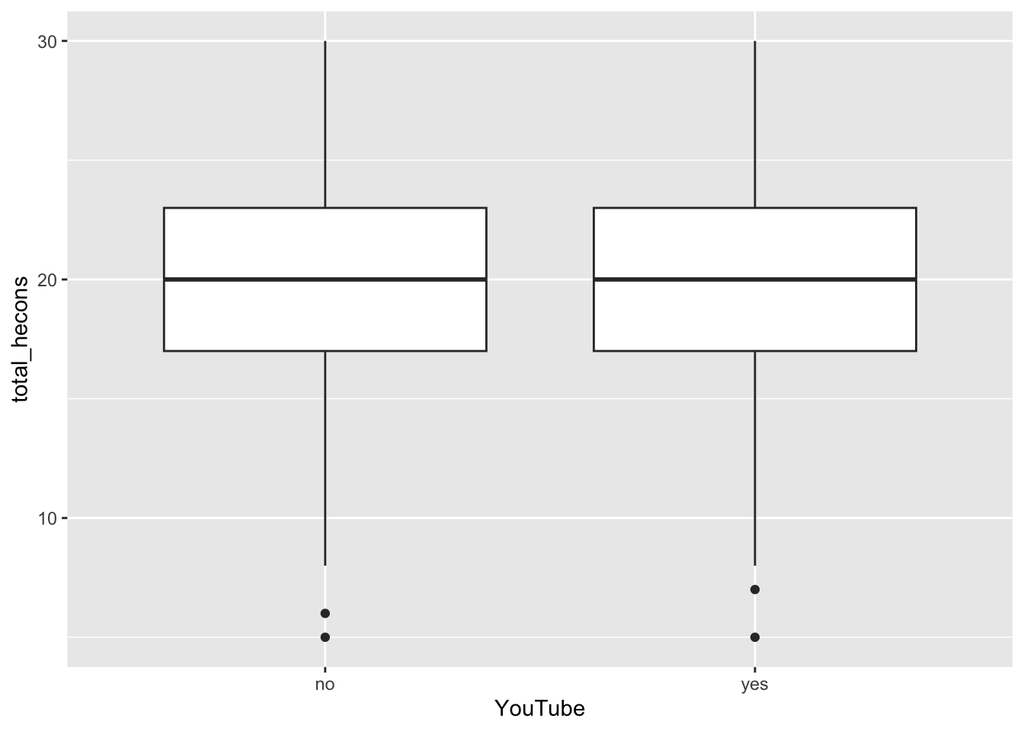

```r
ggplot(hecons_youtube_subset, aes(x=YouTube, y=total_hecons))+
  geom_boxplot()
```

The boxplot seems to show no difference in means between the level of health concerns between those who use youtube and those who do not.

Let’s also see the discriptive stats among two groups

```r
describeBy(hecons_youtube_subset, group = hecons_youtube_subset$YouTube)
```

```
##
##  Descriptive statistics by group
## group: no
##              vars   n  mean   sd median trimmed  mad min max range  skew
## total_hecons    1 498 20.02 4.44     20   20.08 4.45   5  30    25 -0.15
## YouTube         2 498  1.00 0.00      1    1.00 0.00   1   1     0   NaN
##              kurtosis  se
## total_hecons    -0.07 0.2
## YouTube           NaN 0.0
## ------------------------------------------------------------
## group: yes
##              vars   n  mean   sd median trimmed  mad min max range  skew
## total_hecons    1 855 20.21 4.24     20   20.22 4.45   5  30    25 -0.06
## YouTube         2 855  2.00 0.00      2    2.00 0.00   2   2     0   NaN
##              kurtosis   se
## total_hecons    -0.08 0.15
## YouTube           NaN 0.00
```

Mean and median seem to be the same among 2 groups. Though, there are practically 2 more times people who use YouTube than those who do not (No(n=498), Yes(n=855)).

Now let’s see the assumption on homogeneity of variances across the groups

```r
leveneTest(hecons_youtube_subset$total_hecons ~ hecons_youtube_subset$YouTube)
```

```
## Levene's Test for Homogeneity of Variance (center = median)
##         Df F value Pr(>F)
## group    1  1.3527  0.245
##       1351
```

Levene’s test shows that the variances are equal as the p-value is higher than .05

So the assumption is met. Other 2 assumptions are met from the previous test. The data is close to normal (recheck on non-parametric test is needed) and independent

Now, let’s run the T-test

```r
t.test(hecons_youtube_subset$total_hecons ~ hecons_youtube_subset$YouTube, var.equal = T)
```

```
##
##  Two Sample t-test
##
## data:  hecons_youtube_subset$total_hecons by hecons_youtube_subset$YouTube
## t = -0.76953, df = 1351, p-value = 0.4417
## alternative hypothesis: true difference in means between group no and group yes is not equal to 0
## 95 percent confidence interval:
##  -0.6646590  0.2901223
## sample estimates:
##  mean in group no mean in group yes
##          20.02209          20.20936
```

The p-value is higher than .05, so it means that we cannot reject the null-hypothesis, meaning that there is no statistically significant difference between the means of level of health concern among the people who use YouTube and those who do not

Now, let’s recheck the results on non-parametric test Wilcoxon’s Test

```r
wilcox.test(hecons_youtube_subset$total_hecons ~ hecons_youtube_subset$YouTube)
```

```
##
##  Wilcoxon rank sum test with continuity correction
##
## data:  hecons_youtube_subset$total_hecons by hecons_youtube_subset$YouTube
## W = 208319, p-value = 0.5081
## alternative hypothesis: true location shift is not equal to 0
```

The p-value here is even higher, meaning that we still cannot reject the null hypothesis.

Conclusion: The null hypothesis is not rejected. There is no statistically siginificant difference in means of level of health concern between the people who use YouTube and those who do not. The mean for 2 groups is around 20.